# Programming R for Analytics - Final Project

Ankit Gupta

October 11, 2015

# Introduction

The project aims to investigate if a significance difference exists between men and women. To analysis the question, the NLSY97 (National Longitudinal Survey of Youth, 1997 cohort) data set will be used. The data set consists of 67 variables including income and gender. Various hypothesis will be performed to check if there really exists a significance difference between income across gender.

For certain section, we will also have a look at the R code responsible for data transformation or hypothesis tests as it will give us a more deeper understanding of the analysis being performed on the data.

*It is important to note that although there may be appear significat correlations between a variable and income across gender, it doesn’t necessarily imply a causal effect and therefore a multivariate model will be deisgned to check the effect of a particular variable in presence of different variables.*

Before we commence the process, let’s take a moment to understand the concept of the gender wage gap and various nunances associated with it.

**Traditional meaning of gender wage gap**

According to the European Commission gender wage gap has been defined as the average difference between men’s and women’s aggregate hourly earnings. It is generally suggested that the wage gap is due to a variety of causes, such as discrimination in hiring, differences in education choices, differences in salary negotiations, differences in the types of positions held by men and women, differences in the pay of jobs men typically go into as opposed to women (especially highly paid high risk jobs), differences in amount of work experience, difference in length of work week, and breaks in employment.

(Source - https://en.wikipedia.org/wiki/Gender_pay_gap)

**The ‘77 Cents on the Dollar’ Myth**

In recent times, various theories have emerged debunking the notion of wage descriminiation across gender. Various factors like number of hours, education, choice of jobs have been attributed in favour of the alternate theory.

So to speak, our analysis will remain objective and neutral to both the theories and will explore both fronts.

# 1. Data Summary

Let’s begin the analysis by loading the given dataset and perform an initial analysis of given variables.

```
## [1] 8984   67
```

```
## 'data.frame':    8984 obs. of  67 variables:
##  $ E8043100: int  0 0 0 0 0 0 0 0 0 0 ...
##  $ E8043200: int  -4 -4 -4 -4 -4 -4 -4 -4 -4 -4 ...
##  $ E8043400: int  -4 -4 -4 -4 -4 -4 -4 -4 -4 -4 ...
##  $ R0000100: int  1 2 3 4 5 6 7 8 9 10 ...
##  $ R0069400: int  1 2 2 2 2 2 2 1 1 1 ...
##  $ R0070000: int  1 2 3 3 2 2 2 1 1 1 ...
##  $ R0323900: int  -4 3 0 -4 3 4 5 -4 1 1 ...
##  $ R0513500: int  10 -4 -4 46 -4 -4 -4 25 -4 -4 ...
##  $ R0514700: int  100 -4 -4 100 -4 -4 -4 100 -4 -4 ...
##  $ R0514800: int  10 -4 -4 0 -4 -4 -4 0 -4 -4 ...
##  $ R0514900: int  0 -4 -4 0 -4 -4 -4 -2 -4 -4 ...
##  $ R0515100: int  100 -4 -4 100 -4 -4 -4 100 -4 -4 ...
##  $ R0536300: int  2 1 2 2 1 2 1 2 1 1 ...
##  $ R0536401: int  9 7 9 2 10 1 4 6 10 3 ...
```

[output cut: 53 more lines]

The given data set contains **67 columns** and **8984 rows**. However, the column names does not convey meaning information about the values they contain. Let’s assign meaninful column names to the data variables to reflect the nature of values they contain.

```
## 'data.frame':    8984 obs. of  67 variables:
##  $ total.incarceration         : int  0 0 0 0 0 0 0 0 0 0 ...
##  $ age.first.incarceration     : int  -4 -4 -4 -4 -4 -4 -4 -4 -4 -4 ...
##  $ length.longest.incarceration: int  -4 -4 -4 -4 -4 -4 -4 -4 -4 -4 ...
##  $ pubid                       : int  1 2 3 4 5 6 7 8 9 10 ...
##  $ teacher.good                : int  1 2 2 2 2 2 2 1 1 1 ...
##  $ feel.safe                   : int  1 2 3 3 2 2 2 1 1 1 ...
##  $ days.religious.activities   : int  -4 3 0 -4 3 4 5 -4 1 1 ...
##  $ perc.flu.next.year          : int  10 -4 -4 46 -4 -4 -4 25 -4 -4 ...
##  $ perc.diploma.by20           : int  100 -4 -4 100 -4 -4 -4 100 -4 -4 ...
##  $ perc.injail.by20            : int  10 -4 -4 0 -4 -4 -4 0 -4 -4 ...
##  $ perc.parent.by20            : int  0 -4 -4 0 -4 -4 -4 -2 -4 -4 ...
##  $ perc.degree_by30            : int  100 -4 -4 100 -4 -4 -4 100 -4 -4 ...
##  $ gender                      : int  2 1 2 2 1 2 1 2 1 1 ...
##  $ bdate.month                 : int  9 7 9 2 10 1 4 6 10 3 ...
```

[output cut: 53 more lines]

With column names assigned to the data set, let’s produce a summary of the complete data set. The summary table displays for every variable a set of descriptive statistics, depending on the type of the variable:

For eg: for Numerical variables, the range, quartiles, median, and mean will be shown.

for Factor variables, a table with frequencies with frequencies will be shown.

for Numerical and factor variables both, the number of missing values will be shown, if there are any.

for Character variables, the length and the class will be shown.

```
##  total.incarceration age.first.incarceration length.longest.incarceration
##  Min.   : 0.000      Min.   :-4.00           Min.   : -4.0
##  1st Qu.: 0.000      1st Qu.:-4.00           1st Qu.: -4.0
##  Median : 0.000      Median :-4.00           Median : -4.0
##  Mean   : 0.165      Mean   :-1.92           Mean   : -2.4
##  3rd Qu.: 0.000      3rd Qu.:-4.00           3rd Qu.: -4.0
##  Max.   :12.000      Max.   :30.00           Max.   :184.0
##      pubid       teacher.good     feel.safe     days.religious.activities
##  Min.   :   1   Min.   :-4.00   Min.   :-4.00   Min.   :-4.000
##  1st Qu.:2249   1st Qu.: 2.00   1st Qu.: 1.00   1st Qu.:-4.000
##  Median :4502   Median : 2.00   Median : 2.00   Median : 0.000
##  Mean   :4504   Mean   : 1.97   Mean   : 1.85   Mean   :-0.624
##  3rd Qu.:6758   3rd Qu.: 2.00   3rd Qu.: 2.00   3rd Qu.: 1.000
##  Max.   :9022   Max.   : 4.00   Max.   : 4.00   Max.   : 7.000
##  perc.flu.next.year perc.diploma.by20 perc.injail.by20 perc.parent.by20
##  Min.   : -4.0      Min.   : -4.0     Min.   : -4.00   Min.   : -4.00
##  1st Qu.: -4.0      1st Qu.: -4.0     1st Qu.: -4.00   1st Qu.: -4.00
##  Median : -4.0      Median : -4.0     Median : -4.00   Median : -4.00
##  Mean   : 16.9      Mean   : 34.2     Mean   : -0.35   Mean   :  4.46
##  3rd Qu.: 30.0      3rd Qu.:100.0     3rd Qu.:  0.00   3rd Qu.:  0.00
##  Max.   :100.0      Max.   :100.0     Max.   :100.00   Max.   :100.00
##  perc.degree_by30     gender      bdate.month      bdate.year
##  Min.   : -4      Min.   :1.00   Min.   : 1.00   Min.   :1980
##  1st Qu.: -4      1st Qu.:1.00   1st Qu.: 3.00   1st Qu.:1981
##  Median : -4      Median :1.00   Median : 7.00   Median :1982
##  Mean   : 26      Mean   :1.49   Mean   : 6.56   Mean   :1982
##  3rd Qu.: 75      3rd Qu.:2.00   3rd Qu.:10.00   3rd Qu.:1983
##  Max.   :100      Max.   :2.00   Max.   :12.00   Max.   :1984
##  has.condition     is.sad.dep.f    is.sad.dep.m   enroll.status
##  Min.   :-4.000   Min.   :-4.00   Min.   :-4.00   Min.   :-2.00
##  1st Qu.: 0.000   1st Qu.:-4.00   1st Qu.:-4.00   1st Qu.: 8.00
##  Median : 0.000   Median :-4.00   Median :-4.00   Median : 8.00
##  Mean   :-0.424   Mean   :-3.23   Mean   :-3.17   Mean   : 7.82
##  3rd Qu.: 0.000   3rd Qu.:-4.00   3rd Qu.:-4.00   3rd Qu.: 8.00
##  Max.   : 1.000   Max.   : 2.00   Max.   : 2.00   Max.   :10.00
##  household.networth.p  sample.type         race        grades.8th
##  Min.   :-935251      Min.   :0.000   Min.   :1.00   Min.   :-5.000
##  1st Qu.:     -3      1st Qu.:1.000   1st Qu.:1.00   1st Qu.:-4.000
##  Median :  10500      Median :1.000   Median :4.00   Median :-4.000
##  Mean   :  66450      Mean   :0.751   Mean   :2.79   Mean   :-0.423
```

[output cut: 78 more lines]

```
##  Max.   : 6.00       Max.   : 6.00         Max.   : 6.00
##    debt.at.20     job.type.teen   job.type.adult  total.jobs.adult
##  Min.   :    -4   Min.   :-3.00   Min.   :-3.00   Min.   :-3.00
##  1st Qu.:     0   1st Qu.: 2.00   1st Qu.: 2.00   1st Qu.: 3.00
##  Median :     0   Median : 3.00   Median : 4.00   Median : 5.00
##  Mean   :  3164   Mean   : 3.77   Mean   : 4.84   Mean   : 5.12
##  3rd Qu.:  2800   3rd Qu.: 5.00   3rd Qu.: 7.00   3rd Qu.: 7.00
##  Max.   :200000   Max.   :20.00   Max.   :35.00   Max.   :36.00
##    debt.at.30
##  Min.   :    -4
##  1st Qu.:    -4
##  Median :     0
##  Mean   : 10333
##  3rd Qu.: 11000
##  Max.   :370000
```

# 2. Methodology

In this section we will walk through the entire process starting from data clean up till the model building.

## Dealing with missing values

From the descriptive statistics output, it appears that many variables have the negative values in them, which potentially introduce noise in the data analysis. We will treat all the variables depending on the category they fit in - Numeric or continuous variables, categorical variables or both. with each cateogory of variables, we will understand the meaning of negative values that they hold.

## Handling continuous variables

For all the variables selected as continuous, we will check and assign the values and if found less than 0, we will treat the negative values as NA. According variable description of NLSY data, there are potentially 5 negative values which have been considered as coded values -

- Refusal(-1)
- Don’t Know(-2)
- Invalid Skip(-3)
- VALID SKIP(-4)
- NON-INTERVIEW(-5)

For our data analysis, these coded values can prove to add noise to the data, specially when our main variable under investigation “income” act as a continuous variable.

To assign NA to negative values, a function has been designed, which will accept a character variable containing the variable names identified as continuous. The funtion will traverse through each the vector to check the respective elements assigns NA where ever it locates a negative value.

```r
# function to get column names with negative values

#identify continuous variables
nlsy.continuous.vec <- c("age.first.incarceration", "length.longest.incarceration", "pubid", "perc.flu.next.year", "perc.diploma.by20", "perc.injail.by20", "perc.parent.by20", "perc.degree_by30", "bdate.year", "household.size",  "used.marj.30d",  "weight",  "income", "height.ft", "height.in", "weight.p", "highest.sat.math.07", "highest.sat.verbal.07", "highest.act.07", "spouse.income.last.year")

assignNaToContinuous <- function(x) {

  for(col in x){

    nlsy[[col]][nlsy[[col]] < 0] <- NA

  }

  return(nlsy)

}

nlsy <- assignNaToContinuous(nlsy.continuous.vec)
```

## Dealing with categorical variables

Although all the variables in data set are numeric in nature, a subset of them contain repeating values, indicating that they may represent categories. For eg: variables like gender, race and industry intuitively represent the meaning that they contain. These type of variables should not be left as numeric as doing so will not lead to significant inference. With the help of variables description file, we will assign codes to each reapeating value in a variable.

```r
# Transform nlsy vector variables

nlsy <- transform(nlsy,
                  gender = mapvalues(gender, c(1, 2), c("male", "female")),
                  race = mapvalues(race, 1:4, c("Black", "Hispanic", "Mixed", "Other")),
                  has.condition = mapvalues(has.condition, from = 0:1, to = c("No", "Yes")),
                  is.sad.dep.f = mapvalues(is.sad.dep.f, from = 0:2, to = c("Not True", "Sometimes True", "Often True")),
                  is.sad.dep.m = mapvalues(is.sad.dep.m, from = 0:2, to = c("Not True", "Sometimes True", "Often True")),
                  enroll.status = mapvalues(enroll.status, from = 1:11, to = c("Not enrolled, no high school degree, no GED",   "Not enrolled, GED",    "Not enrolled, high school degree", "Not enrolled, some college",   "Not enrolled, 2-year college graduate",    "Not enrolled, 4-year college graduate",    "Not enrolled, graduate degree",    "Enrolled in grades 1-12, not a high school graduate",  "Enrolled in a 2-year college", "Enrolled in a 4-year college", "Enrolled in a graduate program")),
                  sample.type = mapvalues(sample.type, from = 0:1, to = c("Oversample", "Cross-sectional")),
                  grades.8th = mapvalues(grades.8th, from = 1:13, to = c("Mostly below Ds", "Mostly Ds", "About half Cs and half Ds", "Mostly Cs", "About half Bs and half Cs", "Mostly Bs", "About half As and Bs", "Mostly As", "Other (SPECIFY)", "A's to C's", "Mixed", "Ungraded", "Skipped 8th grade"
)),
                  grades.highschool = mapvalues(grades.highschool, from = 1:13, to = c("Mostly below Ds", "Mostly Ds", "About half Cs and half Ds", "Mostly Cs", "About half Bs and half Cs", "Mostly Bs", "About half As and Bs", "Mostly As", "Other (SPECIFY)", "A's to C's", "Mixed", "Ungraded", "Skipped 8th grade"
)),
                  used.cocdrugs = mapvalues(used.cocdrugs, from = 0:1, to = c("No", "Yes")),
                  prq.help.less.fort = mapvalues(prq.help.less.fort, from = c(4,3,2,1,0), to = c("Strongly Agree", "Agree", "Neither Agree nor Disagree", "Disagree", "Strongly Disagree")),
                  prq.take.care = mapvalues(prq.take.care, from = 4:0, to = c("Strongly Agree", "Agree", "Neither Agree nor Disagree",  "Disagree", "Strongly Disagree")),
                  prq.help.people = mapvalues(prq.help.people, from = 4:0, to = c("Strongly Agree", "Agree", "Neither Agree nor Disagree",  "Disagree", "Strongly Disagree")),
                  prq.look.after = mapvalues(prq.look.after, from = 4:0, to = c("Strongly Agree", "Agree", "Neither Agree nor Disagree",  "Disagree", "Strongly Disagree")),
                  college.type = mapvalues(college.type, from = 1:3, to = c("Public institution", "Private not-for-profit institution", "Private for-profit institution")),
                  highest.degree.before1112 = mapvalues(highest.degree.before1112, from = 0:7, to = c("None", "GED", "High school diploma (Regular 12 year program)", "Associate/Junior college (AA)", "Bachelor's degree (BA, BS)", "Master's degree (MA, MS)", "PhD", "Professional degree (DDS, JD, MD)")),
                  marital.status = mapvalues(marital.status, from = 0:4, to = c("Never-married", "Married", "Separated", "Divorced", "Widowed")),
                  highest.grade = mapvalues(highest.grade, from = c(0, 1, 2, 3, 4, 5, 6, 7, 8, 9, 10, 11, 12, 13, 14, 15, 16, 17, 18, 19, 20, 95), to = c("NONE", "1ST GRADE", "2ND GRADE", "3RD GRADE", "4TH GRADE", "5TH GRADE", "6TH GRADE", "7TH GRADE", "8TH GRADE", "9TH GRADE", "10TH GRADE", "11TH GRADE", "12TH GRADE", "1ST YEAR COLLEGE", "2ND YEAR COLLEGE", "3RD YEAR COLLEGE", "4TH YEAR COLLEGE", "5TH YEAR COLLEGE", "6TH YEAR COLLEGE", "7TH YEAR COLLEGE", "8TH YEAR COLLEGE OR MORE", "UNGRADED")),
                  is.income.past.year = mapvalues(is.income.past.year, from = 0:1, to = c("No", "Yes")),
                  is.spouse.income.past.year = mapvalues(is.spouse.income.past.year, from = 0:1, to = c("No", "Yes")),
                  has.smoked.dli = mapvalues(has.smoked.dli, from = 0:1, to = c("No", "Yes")),
                  has.drank.dli = mapvalues(has.drank.dli, from = 0:1, to = c("No", "Yes")),
                  used.drugs.dli = mapvalues(used.drugs.dli, from = 0:1, to = c("No", "Yes")),
                  describe.weight.2011 = mapvalues(describe.weight.2011, from = 1:5, to = c("Very Underweight", "Slightly Underweight", "About the right weight", "Slightly Overweight", "Very Overweight")),
                  energy.level.4weeks = mapvalues(energy.level.4weeks, from = 1:6, to = c("All of the time", "Most of the time", "A good bit of the time", "Some of the time", "A little of the time", "None of the time")),
                  est.spouse.income.last.year = mapvalues(est.spouse.income.last.year, from = 1:7, to = c("$1 - $5,000", "$5,001 - $10,000", "$10,001 - $25,000", "$25,001 - $50,000", "$50,001 - $100,000", "$100,001 - $250,000", "More than $250,000"))
                  )
```

## Dealing with complex variables

There are certain variables which are both categorical and numeric in nature. To further elaborate on the statement, these variable are numeric by nature and contain numeric values, however, we can not treat all the negative values as NA since apart from the “coded” negative values, there are values which are legitimate as negative.

One approach to handle these type of variables is by assigning the coded values -1, -2, -3, -4, -5 as NA and do not transform the remaining negative values. This will be achieved in the same way as we handled numeric variables.

```r
# handle complex variables
nlsy.complex.continuous <- c("household.networth.p", "household.networth.r", "gross.family.income", "debt.at.20", "debt.at.30")

handleComplexContinuous <- function(x){

  for(col in x){

    nlsy[[col]][nlsy[[col]] %in% c(-1, -2, -3, -4, -5)] <- NA

  }

  return(nlsy)

}


nlsy <- handleComplexContinuous(nlsy.complex.continuous)
```

**INDUSTRY** variable contain many numberic values, but these values are considered to be codes, specific to particular industry. We will group the codes and assign appropriate industry codes to each group.

```r
# handle industry variable
nlsy$industry[nlsy$industry %in% 170:290] <- "AGRICULTURE, FORESTRY AND FISHERIES"
nlsy$industry[nlsy$industry %in% 370:490] <- "MINING"
nlsy$industry[nlsy$industry %in% 570:690] <- "UTILITIES"
nlsy$industry[nlsy$industry %in% 770] <- "CONSTRUCTION"
nlsy$industry[nlsy$industry %in% 1070:3990] <- "MANUFACTURING"
nlsy$industry[nlsy$industry %in% 4070:4590] <- "WHOLESALE TRADE"
nlsy$industry[nlsy$industry %in% 4670:5790] <- "RETAIL TRADE"
nlsy$industry[nlsy$industry %in% 5890] <- "ENTERTAINMENT & RECREATION SERVICES"
nlsy$industry[nlsy$industry %in% 6070:6390] <- "TRANSPORTATION & WAREHOUSING"
nlsy$industry[nlsy$industry %in% 6470:6780] <- "INFORMATION & COMMUNICATION"
nlsy$industry[nlsy$industry %in% 6870:7190] <- "FINANCE, INSURACE & REAL ESTATE"
nlsy$industry[nlsy$industry %in% 7270:7790] <- "PROFESSIONAL & RELATED SERVICES"
nlsy$industry[nlsy$industry %in% 7860:8470] <- "EDUCATIONAL, HEALTH & SOCIAL SERVICES"
nlsy$industry[nlsy$industry %in% 8560:8690] <- "ENTERTAINMENT, ACCOMODATIONS, AND FOOD SERVICES"
nlsy$industry[nlsy$industry %in% 8770:9290] <- "OTHER SERVICES"
nlsy$industry[nlsy$industry %in% 9370:9590] <- "PUBLIC ADMINISTRATION"
nlsy$industry[nlsy$industry %in% 9670:9890] <- "ACTIVE DUTY MILITARY"
nlsy$industry[nlsy$industry %in% 9950:9990] <- "ACS SPECIAL CODE"
```

```r
# handle spouse estimated income
nlsy$est.spouse.income.last.year[nlsy$est.spouse.income.last.year %in% c(-1,-2, -3, -4, -5)] <- "?"
```

The final step of data transformation involves factorizing categorical variables that we mapped earlier. Categorical variables will be used extensively in our analysis to differentiate income across gender in presence of a categorical variable. This is will give us a better perspective about the underlying notion of gender wage gap, if it exists.

We will use a funtion to pass a vector of variable names in the function and factorize them. Also, let’s create an age column for our analysis with the help of year of birth variable.

## Dealing with top coded values

It is know through variable description file that income variable is topcode which means that the income of top 2% earners is not known, rather their income has been recorder as the average value of top 2% earner. Let’s take a look at the income of top 2% earners.

```
##    Min. 1st Qu.  Median    Mean 3rd Qu.    Max.
##  146000  146000  146000  146000  146000  146000
```

We observe that there is indeed a single income value for top 2% earners i.e. $146,000.

With the help of a basic plot, let’s analyse the count of males against females in the population of 2% earners.

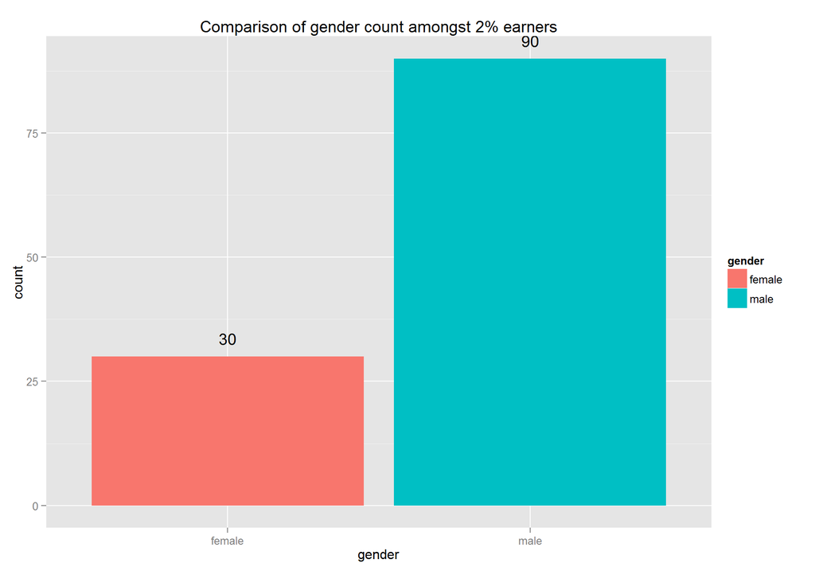

**Takeaway** - A striking difference of 30 women against 90 men in top 2% earners. Top earners generally reflect employees with higher positions. This gives an initial impression that women may not be a natural choice for higher position, though it cannot be concluded cogently without further analysis.

For our analysis, we will remove data pertaining to top 2% earners and their income values will skew the distribution and add much more to the variation than what is expected from a good model.

## Trivial Variables

During my analysis, entailed in subsequent Fining sections, I was expected Age and Education to provide significant findings and trends to indicate an association with difference in mean income across gender. Although, the variables do indicate a difference, however, but the differences are rather unexplained and require more coverage and data points along with other factors outside the scope of the given data set.

## Potentially Significant relationships

With data transformation complete, we begin our core analysis by identifying the subset of variables that will be considered for further investigation and model building.

We will pick the variables that closesly resembles the factors discussed in Introduction section, effecting gender wage gap and the alternate theory. Following are the variables that serves as the starting point for analysis -

- income - Income of inidividual
- gender - Gender of individuals
- industry - Type of Industry that the individual worked in
- age - Age of individual
- race - Race of individual
- college.type - Type of college that the inidividual attended
- enroll.status - Enrollment status of the individual
- job.type.adult - No. of different types of jobs that individual held as adult
- is.spouse.income.past.year - Did spouse of the individual receive income last year?
- spouse.income.last.year - Income of spouse received last year
- household.size - No. of members in family
- hh.member.under6 - No. of members under age 6 in family
- hh.member.under18 - No. of members under age 18 in family

It is likely that not all variables listed above may contribute significantly in our analysis, which we are going to analyse individually using hypothesis tests and using a multi-variate model in the end.

In the following section, we will discuss all the listed variables in detail using table summaries and graphs and summarise the variable with the help of **Takeaway** or interpretation of the graphs.

# 3. Findings

## Variables of interests -

### Gender

```
##   gender income
## 1 female  28595
## 2   male  34310
```

```
##   gender income.0% income.10% income.20% income.30% income.40% income.50%
## 1 female         0       6000      12000      17540      22000      26000
## 2   male         0      10000      16000      22000      27000      32000
##   income.60% income.70% income.80% income.90% income.100%
## 1      30000      36000      43000      53000       94000
## 2      36000      43000      50000      63000       94000
```

If we look at the quantile data of income across gender, we observe that the difference in income progressively increase from low earners to top earners and finally coverging to a maximum income value. The identical highest value could be in indicator of top earners in a given industry supporting the contention of alternate theory.

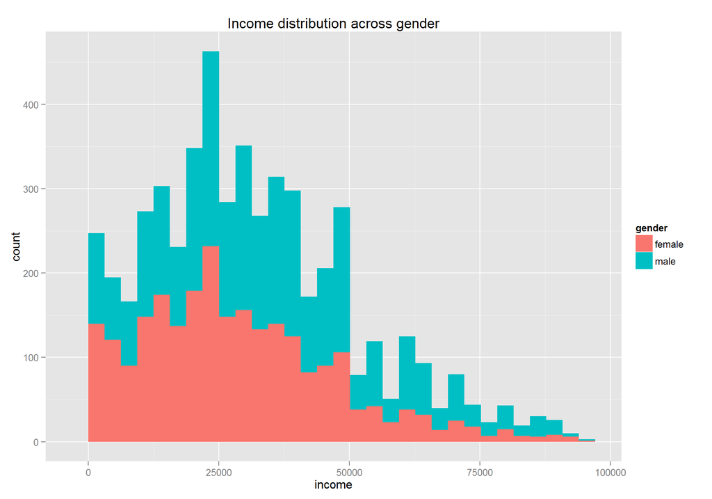

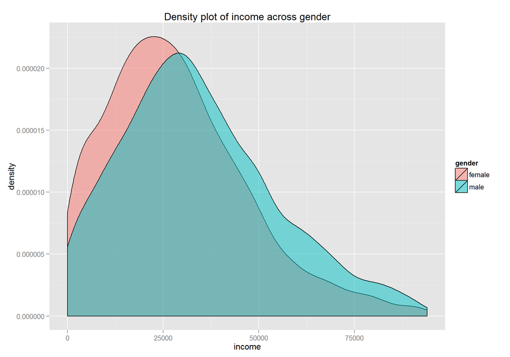

**Takeaway** The histogram of income distributions and density plots indicates a significant difference in income across genders. An interesting point to note here is that the difference is maximum at the mean and progressive converges untill at the tail of distributions.

### Industry

We will start with analysing mean difference in income between men and women and propotion of women across industries.

```
##                                           industry mean.gap mean.ratio
## 1                                                ?    11779       0.63
## 2                                 ACS SPECIAL CODE   -15167       1.71
## 3                             ACTIVE DUTY MILITARY    22684       0.57
## 4              AGRICULTURE, FORESTRY AND FISHERIES    16959       0.56
## 5                                     CONSTRUCTION     7019       0.80
## 6            EDUCATIONAL, HEALTH & SOCIAL SERVICES     3774       0.89
## 7  ENTERTAINMENT, ACCOMODATIONS, AND FOOD SERVICES     3674       0.85
## 8                  FINANCE, INSURACE & REAL ESTATE     6216       0.85
## 9                      INFORMATION & COMMUNICATION     1017       0.97
## 10                                   MANUFACTURING     4504       0.88
## 11                                          MINING    22600       0.56
## 12                                  OTHER SERVICES     5373       0.81
## 13                 PROFESSIONAL & RELATED SERVICES     2718       0.92
## 14                           PUBLIC ADMINISTRATION     8022       0.83
```

[output cut: 23 more lines]

Let’s plot a bar graph to visually represent the figures for a better interpretation.

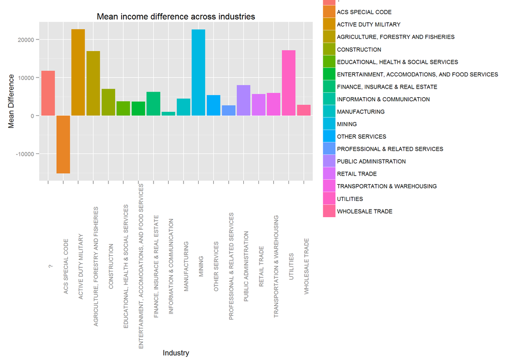

**Takeaway** - By looking at the figures, it is clear that there is wage gap spread across industries. But makes it more interesting is the possibility of choice or a bias towards industry. The mean.gap column in the figure represents mean income difference between men and women. Mean.ratio represents amount earned by women in an industry per $1 earned by men. For instance mean ratio of .57 in Active Duty Military indicates that per $1 earned by men, women earn 57 cents. Proportion.female indicates percentage of females working in an industry according to sample data.

The data suggests particularly for lowest mean.ratio values such as Active Duty Military, Mining where proportion of female is strikingly low, that there may be a biasness towards industry that women target to work in. It can be possible that women choose to work where hard labour is minimum. This is representative in data as well. Industries such as Educational, Health & Services and Information & Communication have significantly higher proportion of women and the mean ratio of income almost matches to that of men.

Industry definitely has a strong association with wage gap.

### Age

We will start with analysing mean difference in income between men and women across age groups.

```
##   age mean.gap mean.ratio
## 1  27     4029       0.87
## 2  28     5852       0.82
## 3  29     5372       0.85
## 4  30     6340       0.83
## 5  31     7343       0.80
```

Let’s plot a bar graph to visually represent the figures for a better interpretation.

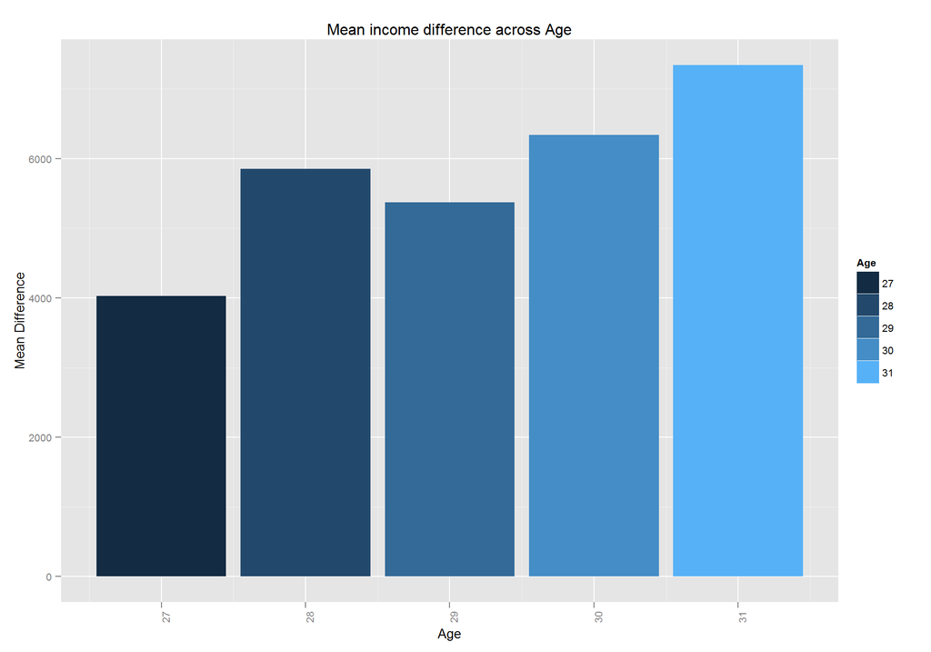

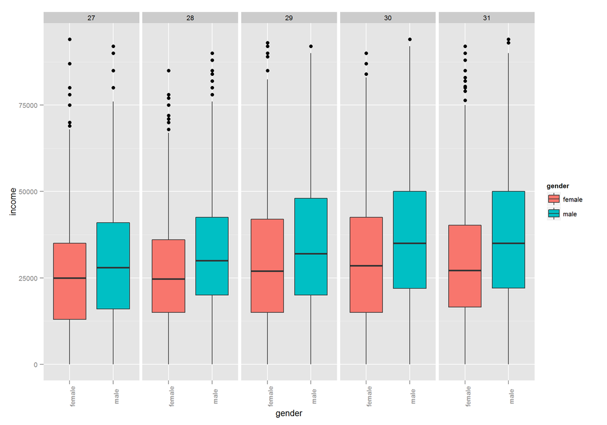

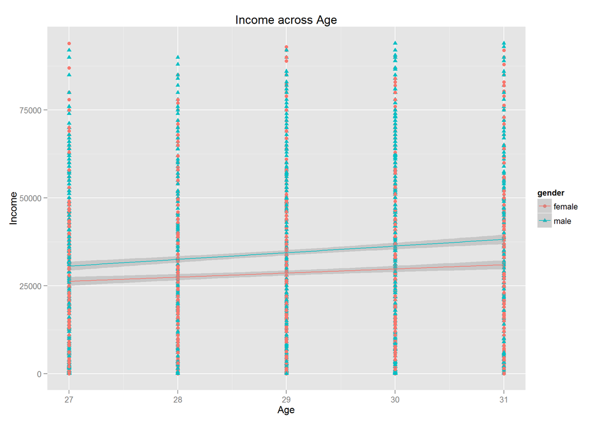

**Takeaway** The above graph has an interesting interpretation that as age increases, the income of men can increase more than women at same age group level. This is indicative from the rise in slope for men against women.

Age seems to have an association with wage gap.

### Race

```
##   gender Black Hispanic Mixed Other
## 1 female 25493    26315 30814 30928
## 2   male 28109    34100 38714 36671
```

```
##       race mean.gap median.gap mean.ratio
## 1    Black     2616       2000       0.91
## 2 Hispanic     7785       7000       0.77
## 3    Mixed     7900       9000       0.80
## 4    Other     5743       7000       0.84
```

Let’s plot a bar graph to visually represent the figures for a better interpretation.

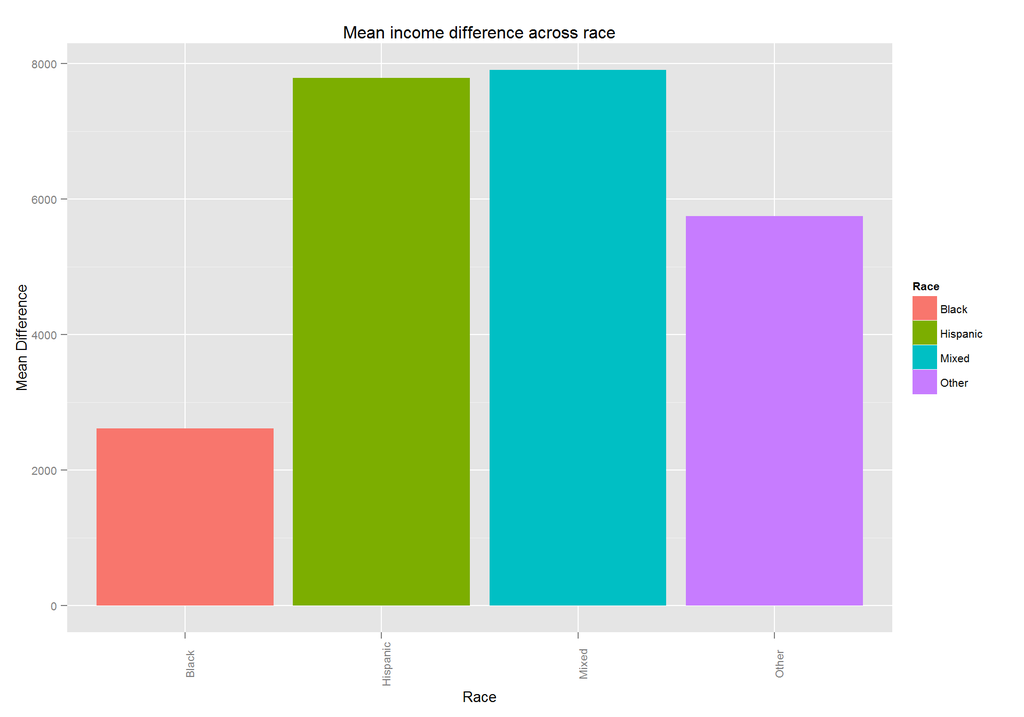

**Takeaway** Race comes out as strong indicator of mean difference in incomes across gender. The mean difference in incomes varies across races quite significantly with difference being lowest amongst Blacks and highest amongst Mixed races. This could be attributed to the fact there are strong policy measures in interests of Blacks to protect their rights.

### Education

We will now analyse various sub factors associated with education that may affect difference in mean income.

```
##   gender     ? Private for-profit institution
## 1 female 29186                          25062
## 2   male 34718                          30491
##   Private not-for-profit institution Public institution
## 1                              33833              25311
## 2                              40547              30686
```

```
##                         college.type mean.gap median.gap mean.ratio
## 1                                  ?     5531       6000       0.84
## 2     Private for-profit institution     5428       5000       0.82
## 3 Private not-for-profit institution     6713       7000       0.83
## 4                 Public institution     5375       4000       0.82
```

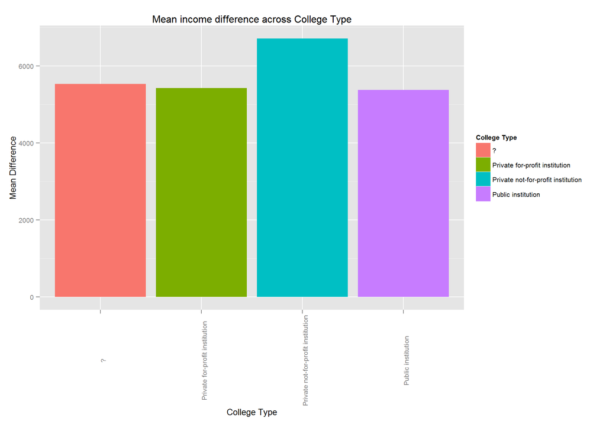

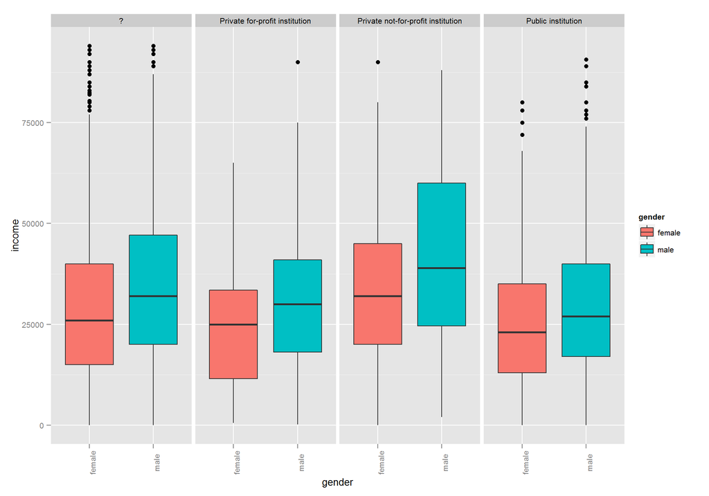

**Takeaway** From the data and graphs, it appears that mean difference in income exists but stays uniform inrrespective of the type of college one may attended. Interestingly there is a spike observed for Private not-for-profit institution. It could be attributed to the type of courses and jobs that women may target post the completion of their courses, however, only the by the graphs they stand unexplained.

```
##                                         enroll.status mean.gap median.gap
## 1                                                   ?      NaN         NA
## 2                        Enrolled in a 2-year college      NaN         NA
## 3                        Enrolled in a 4-year college      NaN         NA
## 4 Enrolled in grades 1-12, not a high school graduate     5715       6000
## 5                                   Not enrolled, GED      NaN         NA
## 6                    Not enrolled, high school degree      NaN         NA
## 7         Not enrolled, no high school degree, no GED     7504       2800
##   mean.ratio
## 1        NaN
## 2        NaN
## 3        NaN
## 4       0.83
## 5        NaN
## 6        NaN
## 7       0.72
```

**Takeaway** Enrollment status does not yield much information and clearly is not a good indicator for wage gap analysis.

### Type of jobs held as adult

```
##   gender    -3     0     1     2     3     4     5     6     7     8     9
## 1 female 24563 35792 30246 30281 30709 30324 29568 28441 28275 28774 26767
## 2   male 26667 49597 40239 40357 38275 38507 36187 34272 29990 30460 28056
##      10    11    12    13    14    15    16    17    18    19    20    21
## 1 27023 25647 22284 27047 25761 20186 24382 17500 15667 22750 10000  9000
## 2 28018 27910 25142 21406 26068 28821 22000 22286 15620 21375   400 22733
##      22    23   24   29   35
## 1 17250 25658 8000   NA   NA
## 2 16000    NA   NA 8500 5400
```

```
##    job.type.adult mean.gap median.gap mean.ratio
## 1              -3  2104.02       5000       0.92
## 2               0 13805.69      17000       0.72
## 3               1  9993.25      14000       0.75
## 4               2 10075.99      10000       0.75
## 5               3  7566.29       8879       0.80
## 6               4  8182.40       7000       0.79
## 7               5  6619.29       5500       0.82
## 8               6  5830.27       4000       0.83
## 9               7  1715.01        500       0.94
## 10              8  1685.72       3000       0.94
## 11              9  1289.08       1000       0.95
## 12             10   995.41       2000       0.96
## 13             11  2263.75       7000       0.92
## 14             12  2857.58          0       0.89
## 15             13 -5640.73      -9000       1.26
## 16             14   306.95       2000       0.99
## 17             15  8635.93       7500       0.70
## 18             16 -2381.82       5000       1.11
## 19             17  4785.71      10750       0.79
## 20             18   -46.67      -4000       1.00
## 21             19 -1375.00        250       1.06
## 22             20 -9600.00      -9600      25.00
## 23             21 13733.33      13000       0.40
## 24             22 -1250.00       3500       1.08
## 25             23      NaN         NA        NaN
## 26             24      NaN         NA        NaN
## 27             29      NaN         NA        NaN
## 28             35      NaN         NA        NaN
```

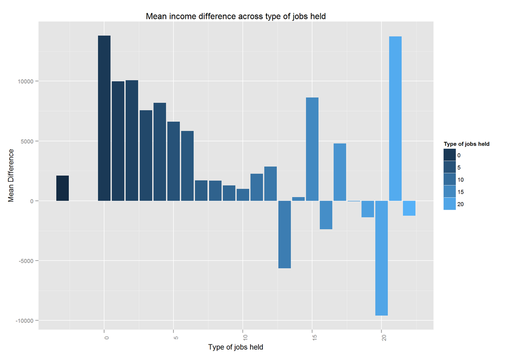

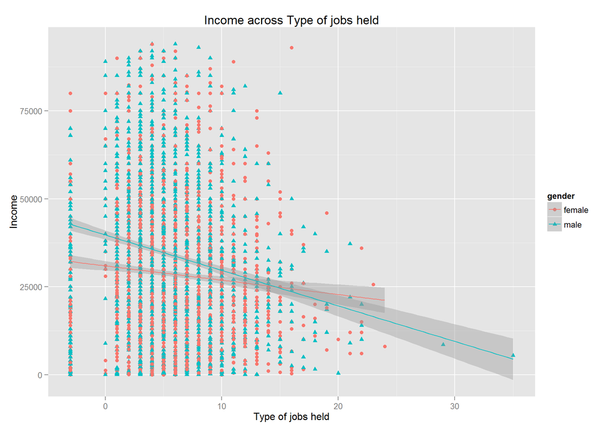

**Takeaway** From the data and table, it appears that the mean difference tends to decrease as number of different type of jobs increase amongst men and women. The fitted line plot however, indicates an interesting trend that as men hold more number of jobs, their income fall much more steeply than women. This could be due to the presence of outliers in the data as we seen in the graph which causes a sudden change in the slope.

More number of different type of jobs can be attributed to different odd jobs or secondary jobs that individual may take. Steady jobs usually pay more than secondary jobs and thus we see a fall in income.

### Spouse

We will now analyse and discuss factors associated with the income details of an individual’s spouse and whether it attributes to difference in mean incomes.

```
##   gender     ?    No   Yes
## 1 female 28223 25053 29311
## 2   male 30396 38148 37207
```

```
##   is.spouse.income.past.year mean.gap median.gap mean.ratio
## 1                          ?     2174       2397       0.93
## 2                         No    13095      11000       0.66
## 3                        Yes     7896       9000       0.79
```

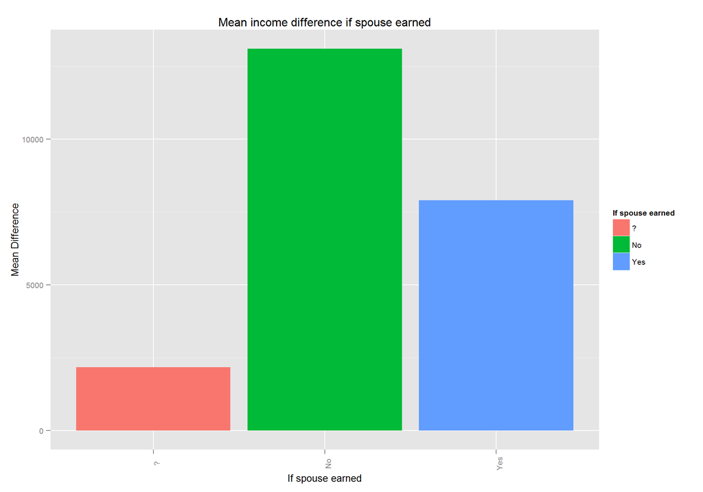

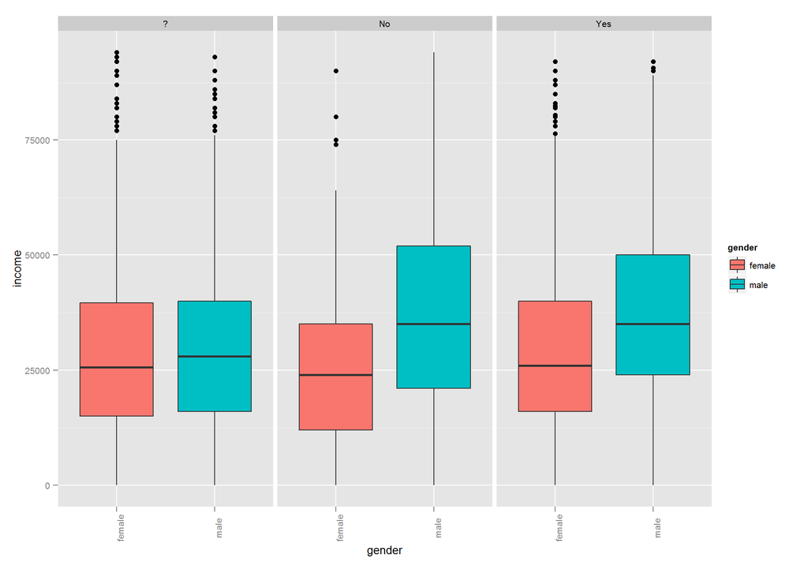

**Takeaway** Both the data and graph suggest significant difference in mean income when spouse of the individual received income last year. The mean difference in income was much higher when the spouse of individual did not receive income. This is expected when observed in daily life. In case of a woman, when her spouse is not working indicate financial problems and she is expected to take odd jobs or secondary jobs which are in general considered to be low paying jobs. Men in general can get skill based jobs irrespective of whether their spouses are working or not.

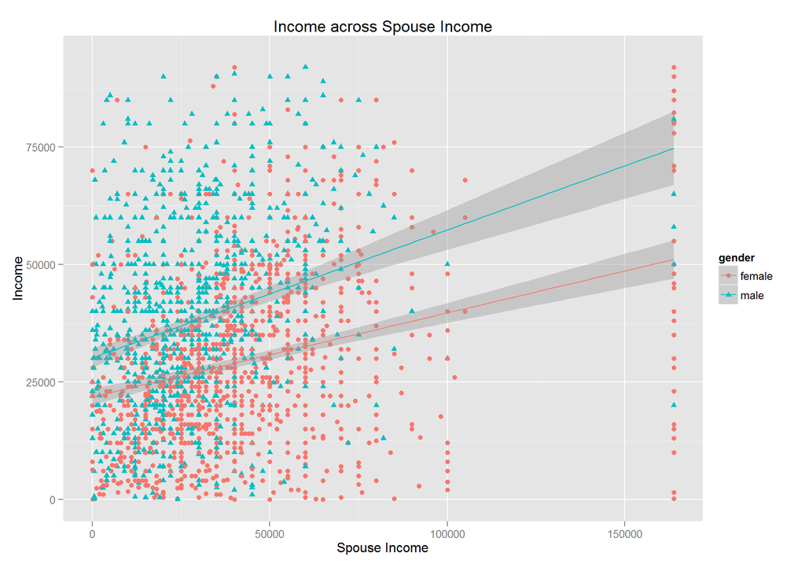

If we plot a fitted line graph of income across gender based on income of spouse, we observe that in general income of both men and and women tend to increase and there is a positive correlation. But, there is an indication of a clear divide between the income of men and women as the slope don’t over lap at any point.

### Family

We will now discuss and analyse factors attributed to difference in mean income by family related variables.

```
##   gender     1     2     3     4     5     6     7     8     9    10    11
## 1 female 36839 32452 30211 26092 20427 19231 18101 20227 20428 14573 27667
## 2   male 36004 34129 33313 35784 33889 33404 27510 26226 30000    NA 26000
##      12    13    15
## 1    NA    NA    NA
## 2 19000 13000 30000
```

```
##    household.size mean.gap median.gap mean.ratio
## 1               1   -834.7      -2000       1.02
## 2               2   1677.2       1000       0.95
## 3               3   3101.3       3000       0.91
## 4               4   9691.5       8000       0.73
## 5               5  13462.5      12000       0.60
## 6               6  14172.7      16500       0.58
## 7               7   9409.2       8250       0.66
## 8               8   5998.9       6000       0.77
## 9               9   9571.9       7680       0.68
## 10             10      NaN         NA        NaN
## 11             11  -1666.7       2000       1.06
## 12             12      NaN         NA        NaN
## 13             13      NaN         NA        NaN
## 14             15      NaN         NA        NaN
```

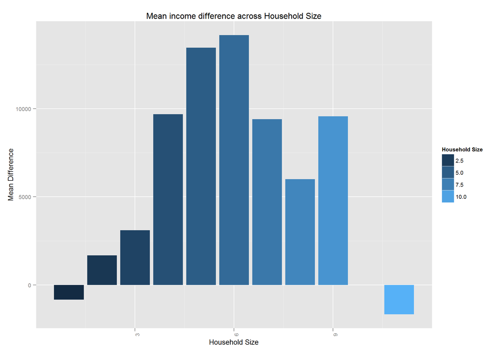

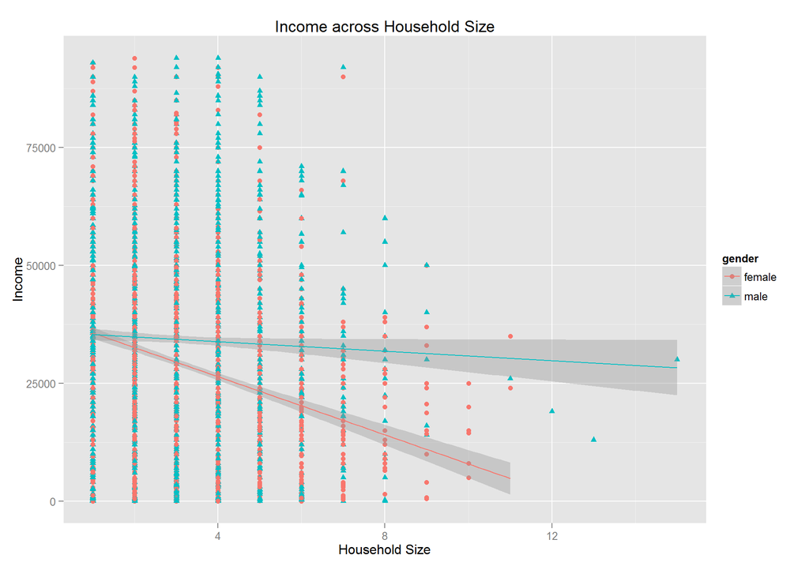

Plotting graphs and tables for members under age 6

```
##   gender     ?     0     1     2     3     4     5
## 1 female 14150 30810 26455 23836 21457 19000 12000
## 2   male 28000 32677 36232 41209 35580 18000    NA
```

```
##   hh.member.under6 mean.gap median.gap mean.ratio
## 1                ?    13850       4000       0.51
## 2                0     1867       1500       0.94
## 3                1     9777      11000       0.73
## 4                2    17373      18000       0.58
## 5                3    14123      15800       0.60
## 6                4    -1000     -10500       1.06
## 7                5      NaN         NA        NaN
```

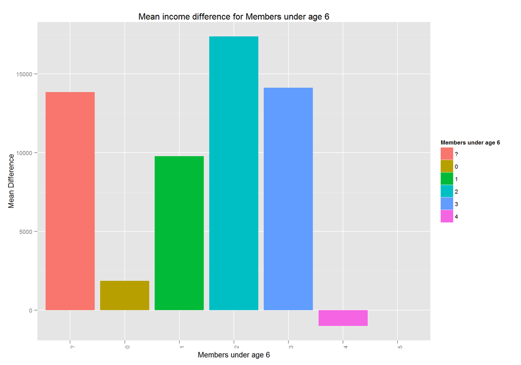

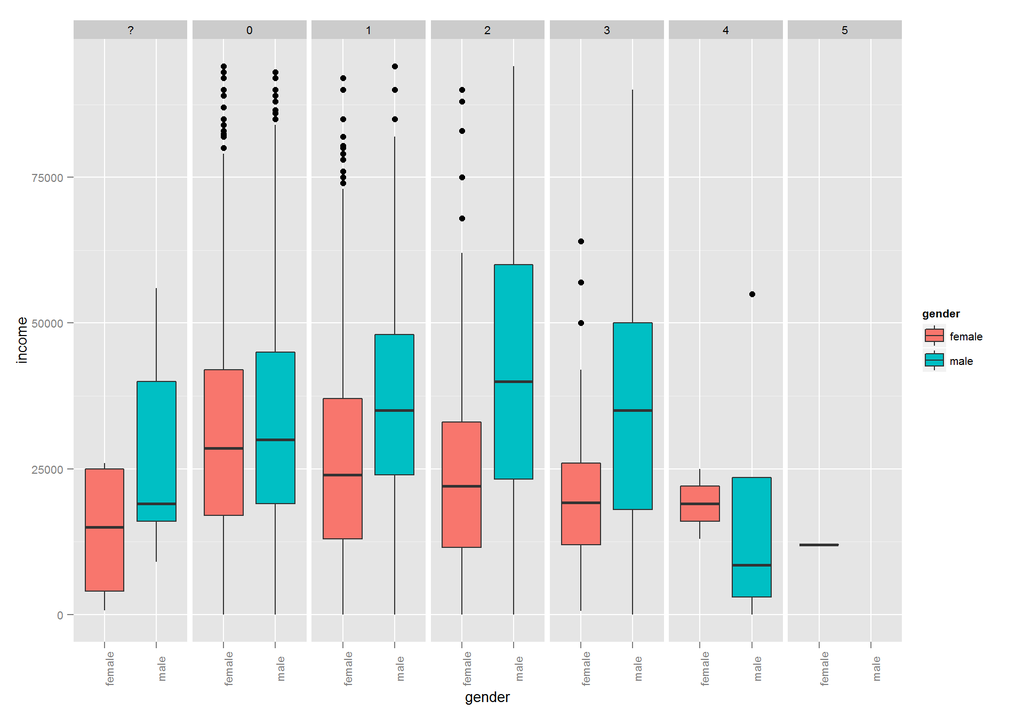

Plotting tables and graphs for members under age 18

```
##   gender     ?     0     1     2     3     4     5     6    7     8     9
## 1 female 14150 33243 29949 26093 19397 16826 13897 17778 4000 24000    NA
## 2   male 28000 33049 34791 37866 35940 35176 30357 22200   NA    NA 30000
```

```
##    hh.member.under18 mean.gap median.gap mean.ratio
## 1                  ?  13850.0       4000       0.51
## 2                  0   -193.5          0       1.01
## 3                  1   4841.5       5500       0.86
## 4                  2  11773.1      11000       0.69
## 5                  3  16542.8      12500       0.54
## 6                  4  18350.3      17000       0.48
## 7                  5  16460.6      10000       0.46
## 8                  6   4422.2      11000       0.80
## 9                  7      NaN         NA        NaN
## 10                 8      NaN         NA        NaN
## 11                 9      NaN         NA        NaN
```

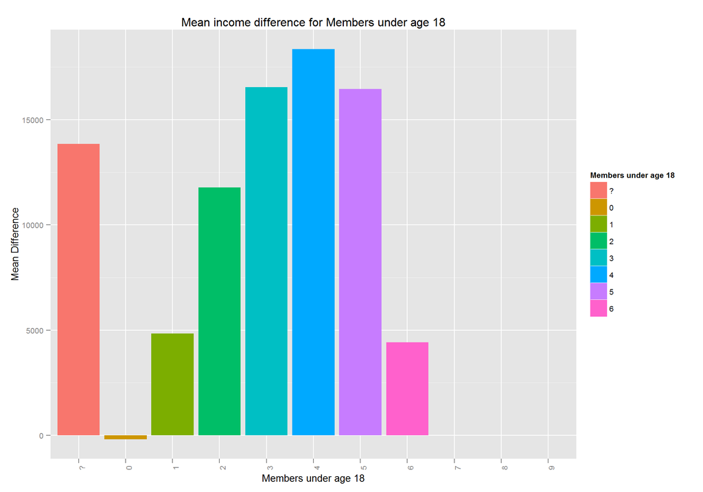

Before we start building our model, let’s analyse if our income data is normal.

For Women

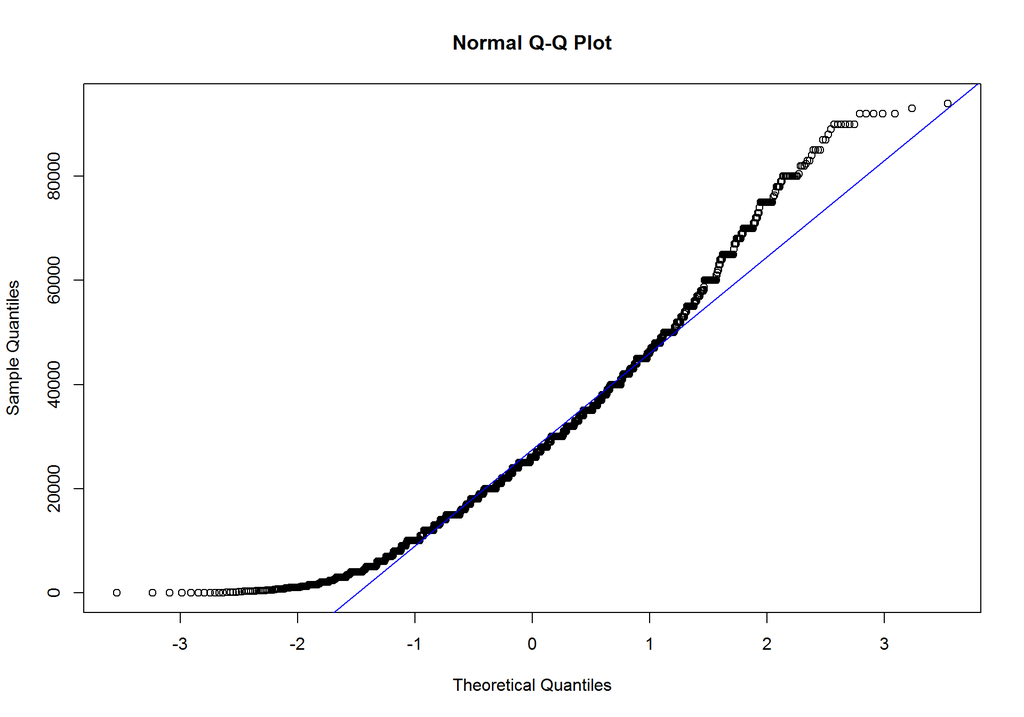

For Men

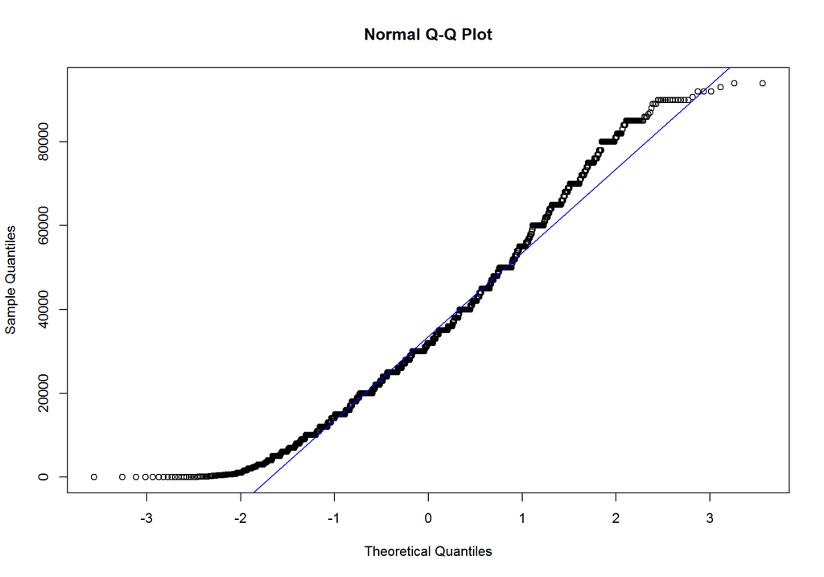

**Takeaway** - From the Normal Q-Q plots, it appears that distribution for men income data is much better than distribution for women income data, but still there is a degree of high variation in the both the distributions.

Our starting point of the regression model to regress income against gender. This type of modelling is simple linear regression. We will keep this model as a baseline reference to check statistical significance of each variable as we add in the model.

```
##
## Call:
## lm(formula = income ~ gender, data = nlsy)
##
## Residuals:
##    Min     1Q Median     3Q    Max
## -34310 -14310  -2595  11405  65405
##
## Coefficients:
##             Estimate Std. Error t value Pr(>|t|)
## (Intercept)    28595        388    73.8   <2e-16 ***
## gendermale      5715        537    10.6   <2e-16 ***
## ---
## Signif. codes:  0 '***' 0.001 '**' 0.01 '*' 0.05 '.' 0.1 ' ' 1
##
## Residual standard error: 19300 on 5180 degrees of freedom
## Multiple R-squared:  0.0214, Adjusted R-squared:  0.0212
## F-statistic:  113 on 1 and 5180 DF,  p-value: <2e-16
```

```
##               R-Squared Residual Standard Error       F-Statistic.value
##                 0.02141             19305.21389               113.31926
```

The output that we see above is of a simple linear model income regressed against gender. The model gives a general interpretation that men tends to earn approximately $5700 more than women. We do not see data of women since they have been added to the baseline. P-value of gender suggests that it is highly significant with significance level of 0.001 and is a good choice of predictor variable.

Let’s run some diagnostic plots the new model.

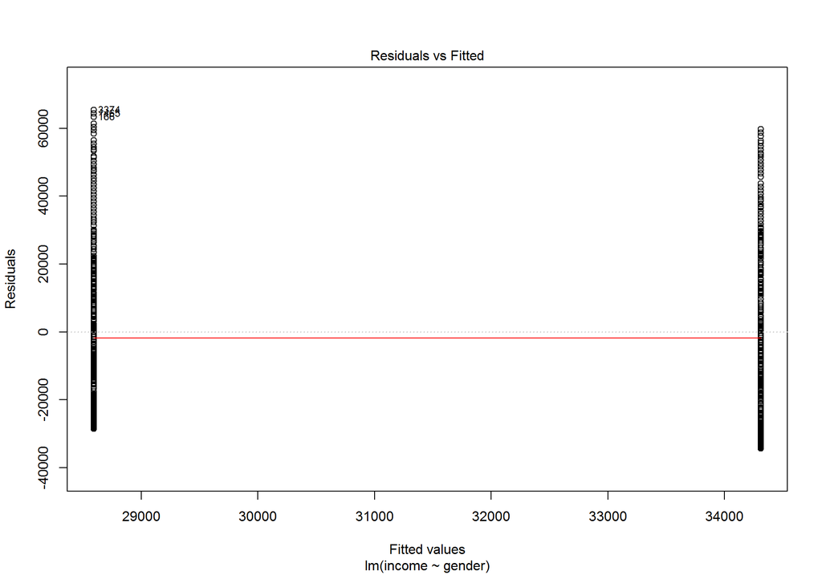

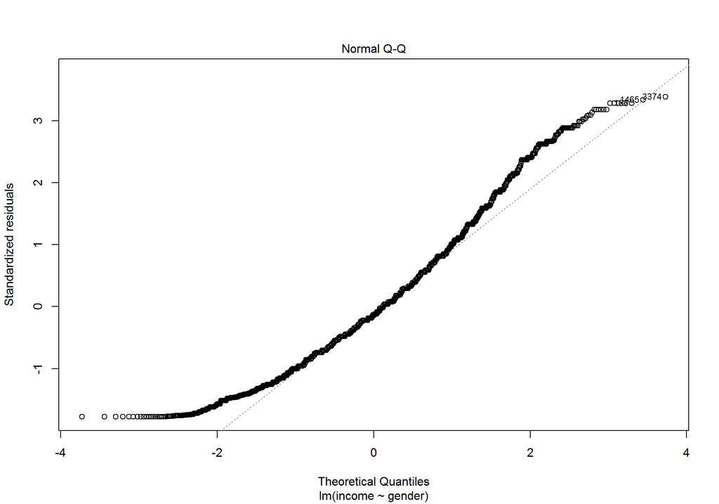

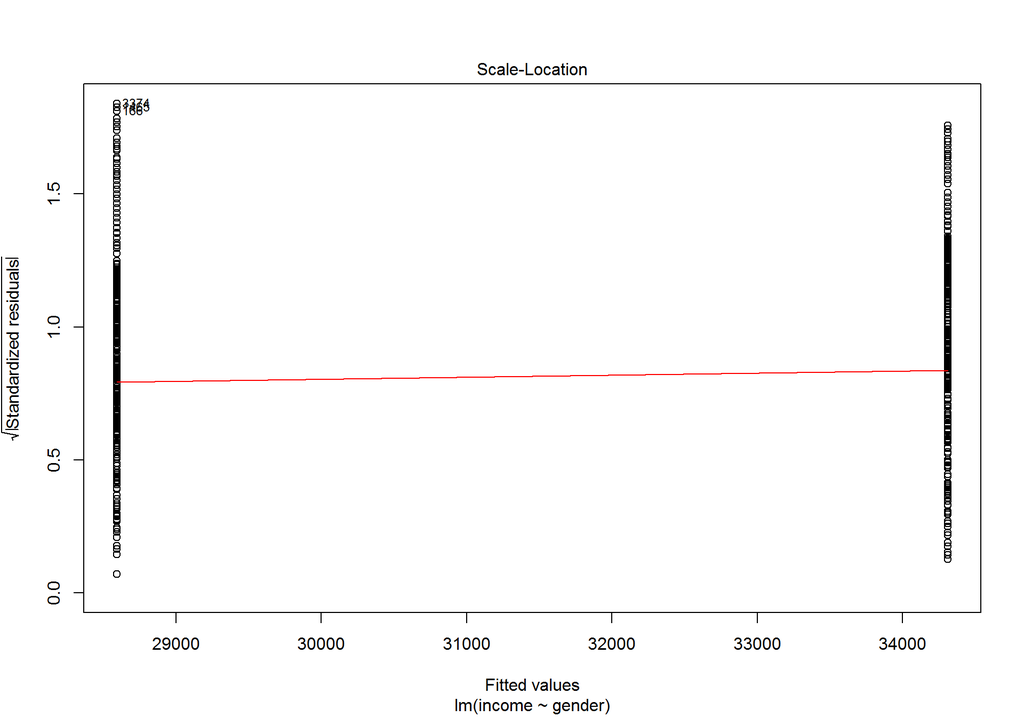

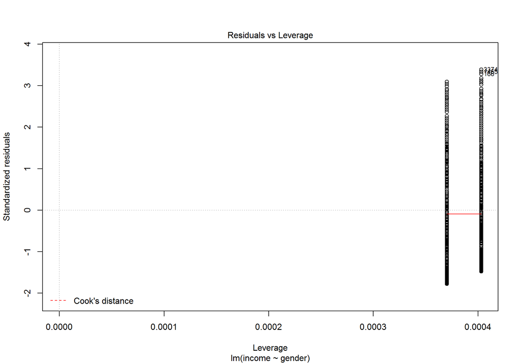

These four plots are important diagnostic tools in assessing whether the linear model is appropriate. The first two plots are the most important, but the last two can also help with identifying outliers and non-linearities.

Residuals vs. Fitted When a linear model is appropriate, we expect

the residuals will have constant variance when plotted against fitted values; and

the residuals and fitted values will be uncorrelated.

If there are clear trends in the residual plot, or the plot looks like a funnel, these are clear indicators that the given linear model is inappropriate.

Normal QQ plot You can use a linear model for prediction even if the underlying normality assumptions don’t hold. However, in order for the p-values to be believable, the residuals from the regression must look approximately normally distributed.

Scale-location plot This is another version of the residuals vs fitted plot. There should be no discernible trends in this plot.

Residuals vs Leverage. Leverage is a measure of how much an observation influenced the model fit. It’s a one-number summary of how different the model fit would be if the given observation was excluded, compared to the model fit where the observation is included. Points with high residual (poorly described by the model) and high leverage (high influence on model fit) are outliers. They’re skewing the model fit away from the rest of the data, and don’t really seem to fit with the rest of the data.

Now let’s create a model using the variables that we have analysed.

```
##               R-Squared Residual Standard Error       F-Statistic.value
##                  0.2017              17519.3426                 25.9299
```

```
## Analysis of Variance Table
##
## Model 1: income ~ gender
## Model 2: income ~ gender + industry + age + race + college.type + enroll.status +
##     job.type.adult + is.spouse.income.past.year + household.size +
##     hh.member.under6 + hh.member.under18
##   Res.Df           RSS Df    Sum of Sq    F Pr(>F)
## 1   5180 1930540846927
## 2   5131 1574844319176 49 355696527751 23.6 <2e-16 ***
## ---
## Signif. codes:  0 '***' 0.001 '**' 0.01 '*' 0.05 '.' 0.1 ' ' 1
```

**Takeaway** If we comapre the above two models, F-statistic and residual errors in the new model have reduced significantly, which is an indication that certainly the new model is a better fit. This is confirmed we observe the p-value from anova test. p-value suggest that it is statistically significant and we should keep the new model.

Let’s run the diagnostic plot again on the new model

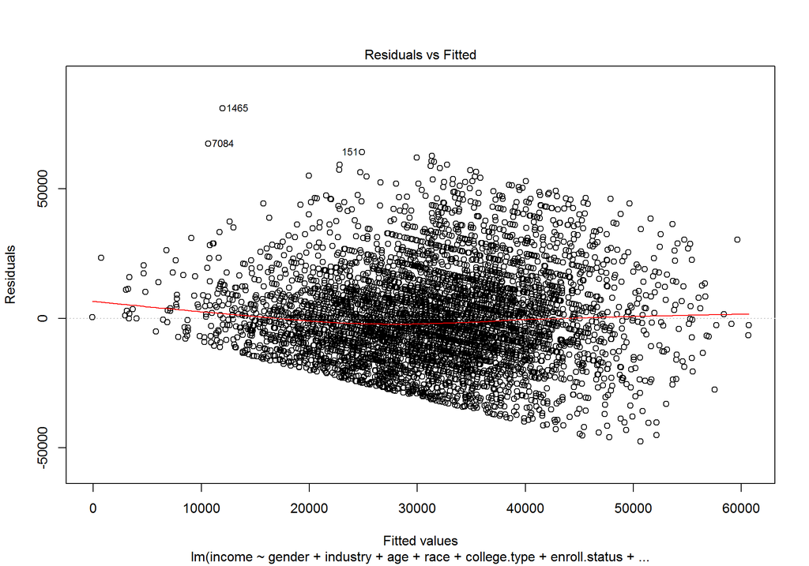

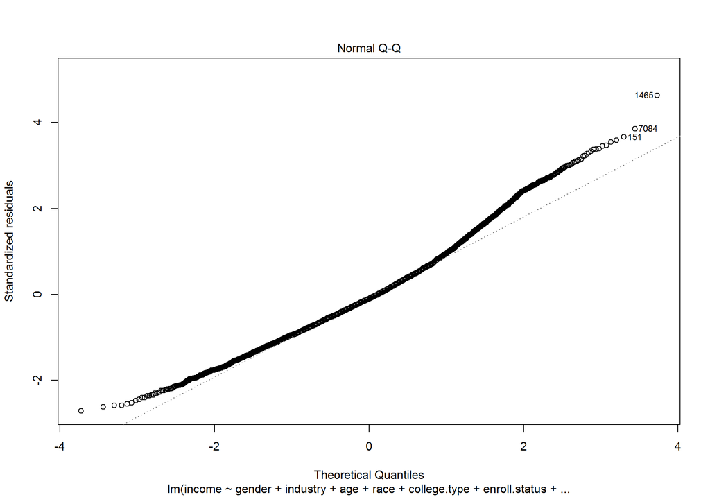

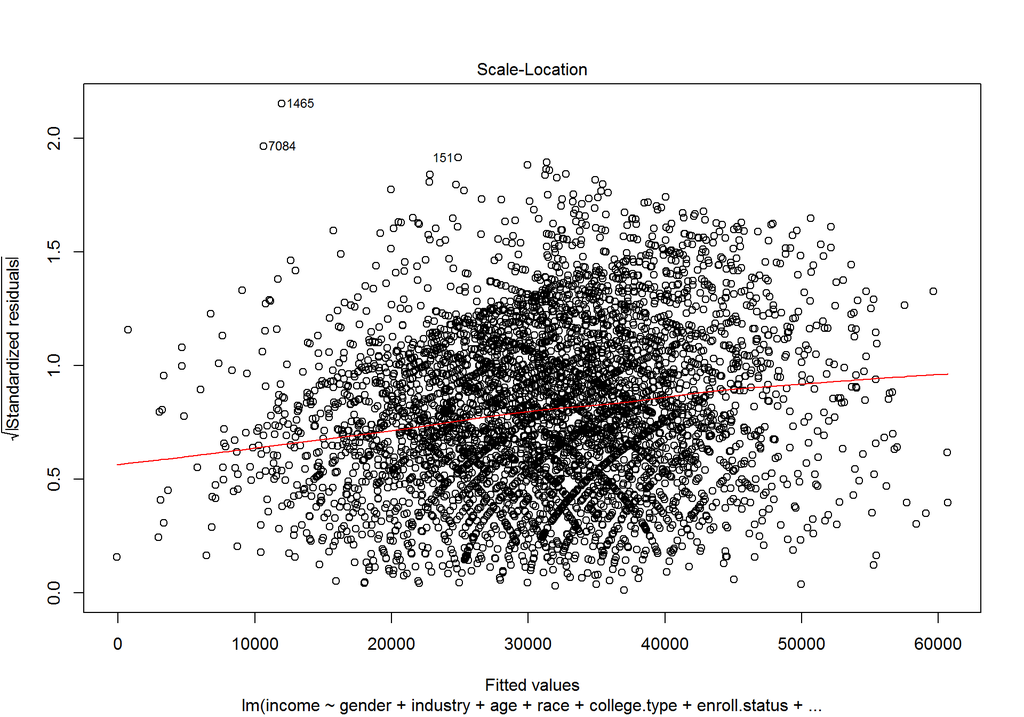

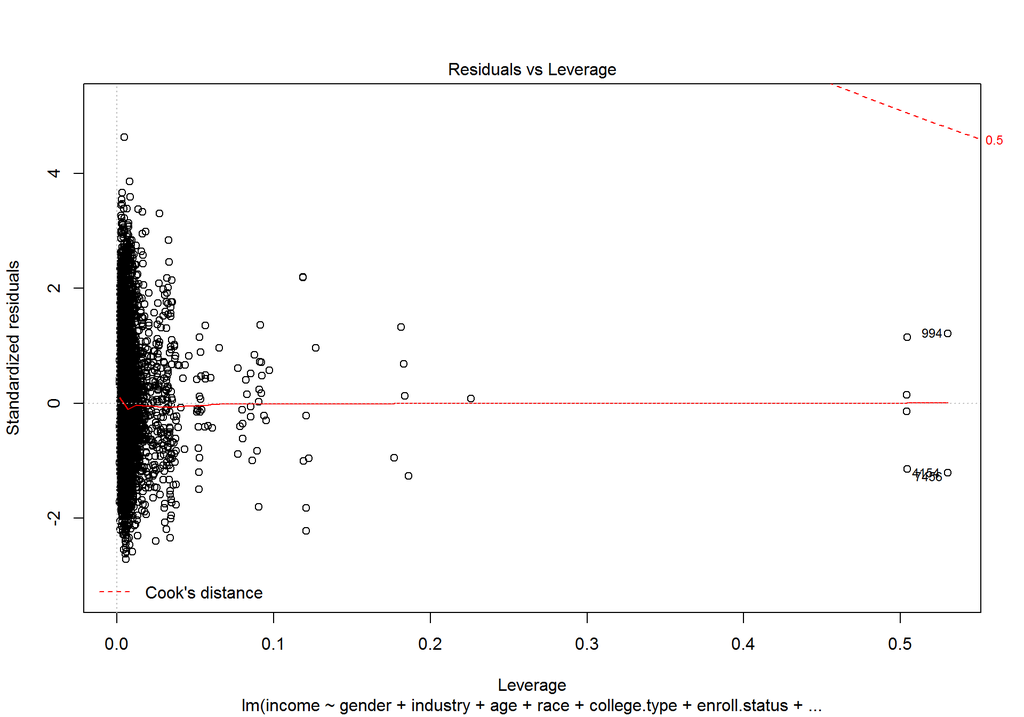

As opposed to our finidings using anova test, we notice visible trends in residuals versus fitted plot and normal qq plot, indicating unexplained residuals or errors in our new model.

Recall from our previous section that we obtained interesting findings from the variables is.spouse.income.past.year, race, household.size. Let’s generate interaction terms with respect to gender from the terms.

```
## Analysis of Variance Table
##
## Model 1: income ~ gender + industry + age + race + college.type + enroll.status +
##     job.type.adult + is.spouse.income.past.year + household.size +
##     hh.member.under6 + hh.member.under18
## Model 2: income ~ gender + industry + age + race + college.type + enroll.status +
##     job.type.adult + is.spouse.income.past.year + household.size +
##     hh.member.under6 + hh.member.under18 + gender:is.spouse.income.past.year +
##     gender:race + gender:household.size
##   Res.Df           RSS Df   Sum of Sq    F Pr(>F)
## 1   5131 1574844319176
## 2   5125 1544974143893  6 29870175283 16.5 <2e-16 ***
## ---
## Signif. codes:  0 '***' 0.001 '**' 0.01 '*' 0.05 '.' 0.1 ' ' 1
```

```
##               R-Squared Residual Standard Error       F-Statistic.value
##                  0.2169              17362.5565                 25.3411
```

|  | Estimate | Std. Error | t value | Pr(>\|t\|) |
| --- | --- | --- | --- | --- |
| (Intercept) | -54911 | 19015 | -2.89 | 0.0039 |
| gendermale | -7319 | 1468 | -4.99 | 0.0000 |
| industryACS SPECIAL CODE | 6279 | 6076 | 1.03 | 0.3014 |
| industryACTIVE DUTY MILITARY | 17309 | 4062 | 4.26 | 0.0000 |
| industryAGRICULTURE, FORESTRY AND FISHERIES | 3020 | 3247 | 0.93 | 0.3524 |
| industryCONSTRUCTION | 4301 | 1532 | 2.81 | 0.0050 |
| industryEDUCATIONAL, HEALTH & SOCIAL SERVICES | 5698 | 1277 | 4.46 | 0.0000 |
| industryENTERTAINMENT, ACCOMODATIONS, AND FOOD SERVICES | -3332 | 1375 | -2.42 | 0.0154 |
| industryFINANCE, INSURACE & REAL ESTATE | 10824 | 1483 | 7.30 | 0.0000 |
| industryINFORMATION & COMMUNICATION | 11261 | 1912 | 5.89 | 0.0000 |
| industryMANUFACTURING | 7925 | 1476 | 5.37 | 0.0000 |
| industryMINING | 21580 | 3169 | 6.81 | 0.0000 |
| industryOTHER SERVICES | -312 | 1589 | -0.20 | 0.8443 |
| industryPROFESSIONAL & RELATED SERVICES | 5196 | 1353 | 3.84 | 0.0001 |
| industryPUBLIC ADMINISTRATION | 15617 | 1627 | 9.60 | 0.0000 |
| industryRETAIL TRADE | -26 | 1376 | -0.02 | 0.9850 |
| industryTRANSPORTATION & WAREHOUSING | 7387 | 1819 | 4.06 | 0.0000 |
| industryUTILITIES | 17710 | 3383 | 5.23 | 0.0000 |
| industryWHOLESALE TRADE | 5944 | 1854 | 3.21 | 0.0014 |
| age | 1839 | 181 | 10.17 | 0.0000 |
| raceHispanic | 1934 | 1074 | 1.80 | 0.0718 |
| raceMixed | 7253 | 3874 | 1.87 | 0.0612 |
| raceOther | 4633 | 918 | 5.04 | 0.0000 |
| college.typePrivate for-profit institution | -2175 | 1375 | -1.58 | 0.1136 |
| college.typePrivate not-for-profit institution | 2818 | 1457 | 1.93 | 0.0530 |
| college.typePublic institution | -3041 | 738 | -4.12 | 0.0000 |
| enroll.statusEnrolled in a 2-year college | 39008 | 21358 | 1.83 | 0.0679 |
| enroll.statusEnrolled in a 4-year college | 27141 | 24647 | 1.10 | 0.2709 |
| enroll.statusEnrolled in grades 1-12, not a high school graduate | 31023 | 17453 | 1.78 | 0.0755 |
| enroll.statusNot enrolled, GED | 19858 | 21376 | 0.93 | 0.3529 |
| enroll.statusNot enrolled, high school degree | 14236 | 21567 | 0.66 | 0.5092 |
| enroll.statusNot enrolled, no high school degree, no GED | 22448 | 17531 | 1.28 | 0.2004 |
| job.type.adult | -848 | 66 | -12.78 | 0.0000 |
| is.spouse.income.past.yearNo | -208 | 1555 | -0.13 | 0.8936 |
| is.spouse.income.past.yearYes | 302 | 785 | 0.38 | 0.7005 |
| household.size | -2689 | 320 | -8.41 | 0.0000 |
| hh.member.under60 | 3695 | 18749 | 0.20 | 0.8438 |
| hh.member.under61 | 6100 | 18743 | 0.33 | 0.7448 |
| hh.member.under62 | 9312 | 18752 | 0.50 | 0.6195 |
| hh.member.under63 | 10267 | 18657 | 0.55 | 0.5821 |
| hh.member.under64 | 6827 | 20124 | 0.34 | 0.7344 |
| hh.member.under65 | 4899 | 25633 | 0.19 | 0.8485 |
| hh.member.under180 | 3074 | 18139 | 0.17 | 0.8654 |
| hh.member.under181 | 416 | 18082 | 0.02 | 0.9816 |
| hh.member.under182 | -360 | 18039 | -0.02 | 0.9841 |
| hh.member.under183 | -2803 | 17991 | -0.16 | 0.8762 |
| hh.member.under184 | -1115 | 17991 | -0.06 | 0.9506 |
| hh.member.under185 | -4165 | 18102 | -0.23 | 0.8180 |
| hh.member.under186 | 268 | 18473 | 0.01 | 0.9884 |
| hh.member.under187 | -884 | 25101 | -0.04 | 0.9719 |
| hh.member.under188 | 14474 | 25041 | 0.58 | 0.5633 |
| gendermale:is.spouse.income.past.yearNo | 8517 | 1912 | 4.45 | 0.0000 |
| gendermale:is.spouse.income.past.yearYes | 5805 | 1083 | 5.36 | 0.0000 |
| gendermale:raceHispanic | 2753 | 1480 | 1.86 | 0.0629 |
| gendermale:raceMixed | 3235 | 5130 | 0.63 | 0.5282 |
| gendermale:raceOther | 2378 | 1255 | 1.89 | 0.0582 |
| gendermale:household.size | 1779 | 335 | 5.31 | 0.0000 |

The new model turns out to be still significant with Residual errors reduced to 17362.5565 and F-statistic reduced to 25.3411. P-value is statistically significant indicating a better model. The new model will be our final mode as we have incorporated all the significant variables and interaction terms within the scope of given dataset.

# 4. Discussion

For our concluding segment, let’s run the diagnostic plot of our final selected model again.

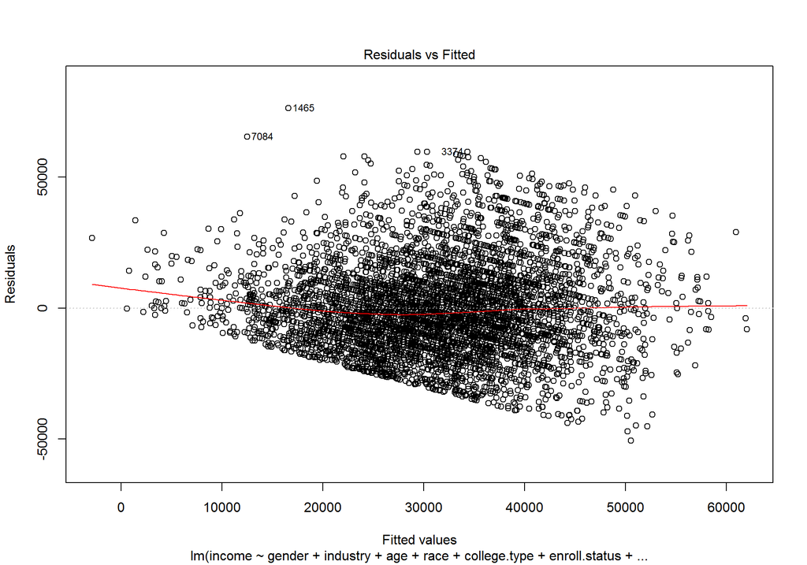

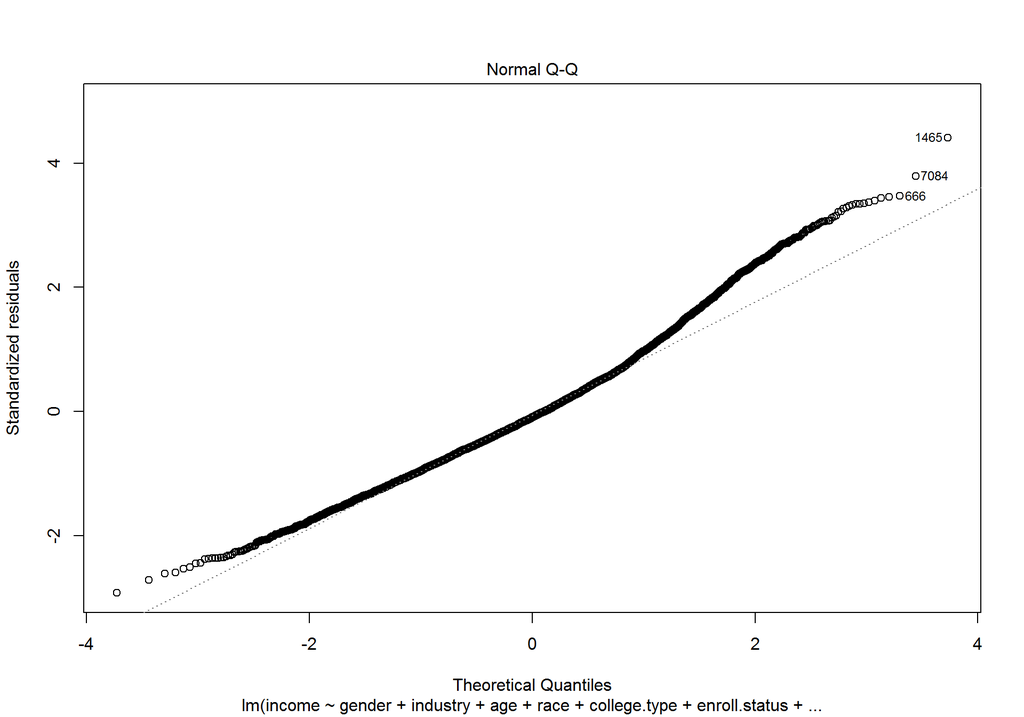

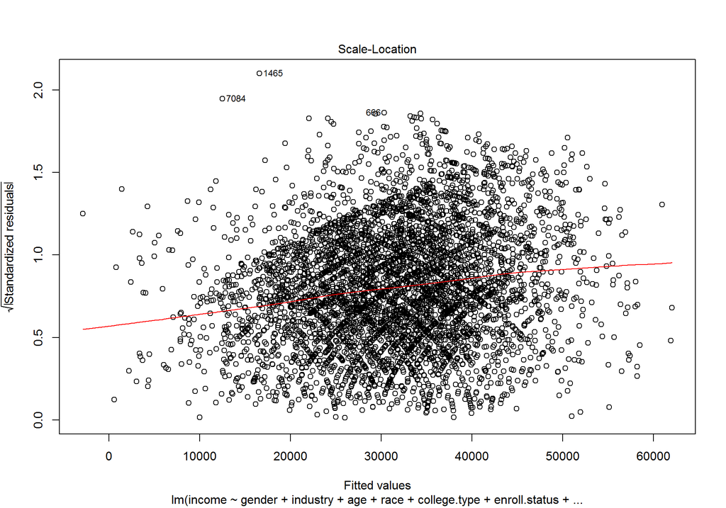

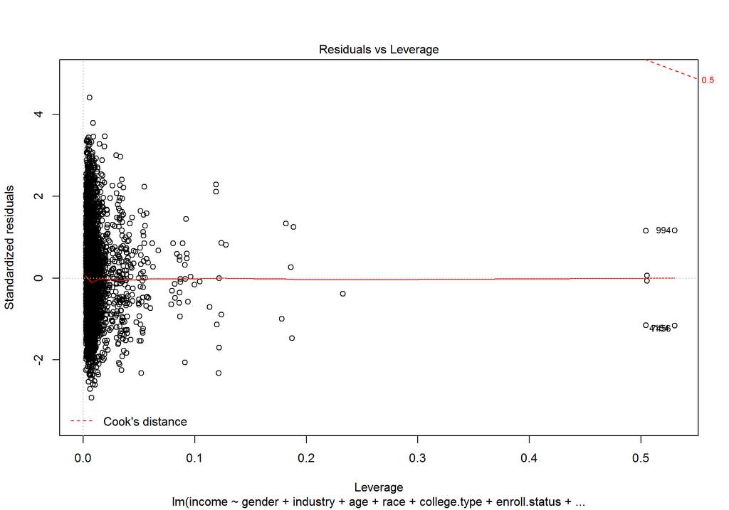

One of the potential limitations in our model selection was that susbet of missing values taken out from the data set reduced the set of data points to a considerable extent. For a model to be a good fit, it is imperative to have large sample sizes that can better explain the variations.

Variables in our model such as enrollment status, mumbers under the age 6 and members under the 18 appear to be statistically insignificant variable, although in our initial discussion, they had interesting statistics to display. However, in presence of different variable, their affect becomes insignificant.

is.spouse.income.past.year although appears as an statistically insignificant, but, as a part part of interaction model along with gender appear to hold statstical significance.

Also, I found several contributing factors like positions, number of working hours and incomes from previous years are missing from the data set. These factors tend to be highly influential when it comes to gender wage gap analysis.

In general I feel that our model may not be the best model, but to a some degree of confidence, it can explain the difference in income across gender keep other variables constant. The model is good for a surface level analysis, but is certainly not equiped to be presented to policy makers in making decisions considering high number of missing values and insufficient contributing variables available in the data set.

Based on the analysis performed, I do feel that wage gap **still exists** based on the survey data, however the extent doesn’t equate to proportions as it is touted to be due to contributing factors like choice of jobs, whether spouse works or not, gravitates more towards the alternate theory.